# Analysis for Stroop

Cooper

2023-07-20

# 1 Introduction:

This R markdown file would be used to do statistical analysis for stroop test. It contains two main parts. In the first part, this file presents R code used to clean dataset. In the second part, this file presents some summary tables according to different regression models.

# 2 Apple Watch Data and GAPCare II Dataset - Baseline

After we have cleaned apple watch data of stroop, we need to choose the Baseline data. There is a csv file recording the relationship between the GAPCare II dataset and apple watch data and also recording the 30-days-followup, 60-days-followup, 90-days-followup, and baseline timelines. Here, we only care about baseline dataset.

```r
library(tidyverse)
library(dplyr)
library(readxl)
library(car)
library(jtools)
library(huxtable)
library(knitr)

#Import Dataset
Stroop_data_original <- read.csv("/Users/dhyscuduke/Desktop/Cleaned_Data_New_Cognition/Cognition_stroop_new.csv")
Trailmaking_data_original <- read.csv("/Users/dhyscuduke/Desktop/Cleaned_Data_New_Cognition/Cognition_trailmakingtest_new.csv")
GAPCare2 <- read.csv("/Volumes/GoldbergLab/GAPCare II/Data/GAPcare II Clinical Trial/GAPcareIIClinicalTri_DATA_LABELS_2023-05-03_1711.csv")
ID_Data <- read.csv("/Users/dhyscuduke/Desktop/GAPcare II Login info - 02.15.2023.csv")

#ID_Data <- select(ID_Data, REDCap.ID, ED.Apple.Watch.Fall.ID)
```

Here is R Code for baseline dataset screened in stroop test:

```r
#Stroop Baseline Screeded
R1 <- as.vector(Stroop_data_original$pt)
Stroop_data_original$selected_nums_stroop <- sub("(\\d{16}).*", "\\1", R1)
Baseline_stroop <- Stroop_data_original[Stroop_data_original$selected_nums_stroop
                                        %in% ID_Data$ED.Apple.Watch.Fall.ID, ]
ID1 <- as.vector(Baseline_stroop$selected_nums_stroop)[!duplicated(as.vector(Baseline_stroop$selected_nums_stroop))]
selected_ID_Data <- ID_Data[ID_Data$ED.Apple.Watch.Fall.ID %in% ID1,]
```

# 3 Stroop Test

In this section, we focus on specific data needed for stroop test and trailmaking test.

## 3.1 Stroop Test

The Stroop test administered in GAPcareII measures executive function via the Stroop effect, defined as the difference in average time to respond to congruent versus incongruent color/text pairs irrespective of correctness. The format of the cleaned iWatch data for the Stroop data are presented in Figures below. Each participant has multiple rows associated with a single test in the data obtained from Redcap. The first column pt identifies the participant. and study visit. The second and third columns, startTime and endTime report the time a given word/color pair was first shown and the time the participant responded, respectively. The fourth and fifth columns, color and text correspond to the color and words shown to the participant, respectively. The sixth and final column, colorSelected reports the participants’ response. Each participant was presented with 15 trials, with the number of congruent varying from person to person. The Stroop effect is then calculated as the difference between the average endTime and startTime on congruent and incongruent trials within a given test.

```r
#Stroop Analysis
data.all <- Baseline_stroop

data.all.summ = data.all%>%
  mutate(time_diff = as.numeric(as.character(endTime))-as.numeric(as.character(startTime)),
         match_text = colorSelected==text,
         match_color = colorSelected==color)
summ = data.all.summ %>%
  group_by(pt)%>%
  summarise(n= n(),
            avg_time_diff = mean(time_diff),
            match_text_p = sum(match_text)/n(),
            match_color_p = sum(match_color)/n(),
            match_both_p = sum(match_text*match_color)/n()
  )

data.all.summ$congruent <- data.all.summ$match_text & data.all.summ$match_color

N1 <- data.all.summ %>% group_by(pt) %>%
  filter(congruent == "TRUE") %>% summarise('1' = mean(time_diff))

N0 <- data.all.summ %>% group_by(pt) %>%
  filter(congruent == "FALSE") %>% summarise('0' = mean(time_diff))

Baseline_stroop <- subset(Baseline_stroop, !duplicated(Baseline_stroop$pt))
Baseline_stroop$N1 <- N1$`1`
Baseline_stroop$N0 <- N0$`0`
Baseline_stroop$effect <- Baseline_stroop$N1 -  Baseline_stroop$N0

for (i in 1:length(Baseline_stroop$pt)){
  Baseline_stroop$ID[i] <- (selected_ID_Data
                            %>% filter(ED.Apple.Watch.Fall.ID
                                       == Baseline_stroop$selected_nums_stroop[i]))$REDCap.ID
}

head(Baseline_stroop)
```

| pt | startTime | endTime | color | text | colorSelected | selected_nums_stroop | N1 | N0 | effect | ID |
| --- | --- | --- | --- | --- | --- | --- | --- | --- | --- | --- |
| 4658593351598080_active_tasks_1_arm_1_cognition_stroop | 7.19e+04 | 7.19e+04 | GREEN | RED | RED | 4658593351598080 | 3.42 | 3.85 | -0.434 | 1889 |
| 4658593351598080_active_tasks_2_arm_1_cognition_stroop | 9.2e+04 | 9.2e+04 | BLUE | GREEN | BLUE | 4658593351598080 | 2.26 | 2.55 | -0.29 | 1889 |
| 4658593351598080_active_tasks_3_arm_1_cognition_stroop | 1.81e+04 | 1.81e+04 | BLUE | YELLOW | YELLOW | 4658593351598080 | 1.9 | 1.82 | 0.0841 | 1889 |
| 4658593351598080_active_tasks_4_arm_1_cognition_stroop | 2.02e+04 | 2.02e+04 | YELLOW | YELLOW | YELLOW | 4658593351598080 | 2.84 | 1.81 | 1.03 | 1889 |
| 4774271542886400_active_tasks_1_arm_1_cognition_stroop | 7.29e+04 | 7.29e+04 | YELLOW | YELLOW | YELLOW | 4774271542886400 | 7.96 | 3.06 | 4.9 | 959 |
| 4811078900908032_active_tasks_1_arm_1_cognition_stroop | 3.46e+05 | 3.46e+05 | YELLOW | YELLOW | YELLOW | 4811078900908032 | 3.33 | 2.05 | 1.28 | 1131 |

# 4 Covariates

Before doing regression analysis, we need to consider the confounders used in regression model. Let $Age_{ij}$ , $Male_i$, $Education_i$, $Assistive Device_{ij}$ , $Fall History_i$, $Head Strike_i$, and $Cognitive Impairment_i$ similarly denote a participant’s age, indicator for gender male, education in years, use of an assistive device for walking, indicator for fall history at initial ED visit, head strike associated with presenting fall, and cognitive impairment as measured by answering three or more of the six item screener questions incorrectly, respectively. We created and cleaned these confounders in R:

```r
#Filter Age, Gender, EDU, Cognitive Impairment, Head Strike, Fall History, and Assistive Devices
GAPCare_Data_Stroop <- GAPCare2 %>% filter(Event.Name == 'ED Visit ') #Filter ED Visit
for (i in 1:length(Baseline_stroop$pt)){
  Baseline_stroop$Age[i] <- (GAPCare_Data_Stroop
                             %>% filter(Record.ID
                                        == Baseline_stroop$ID[i]))$How.old.is.the.patient.as.listed.in.the.chart.

  Baseline_stroop$Gender[i] <- (GAPCare_Data_Stroop
                                %>% filter(Record.ID
                                           == Baseline_stroop$ID[i]))$What.is.the.gender.of.the.patient.as.listed.in.the.chart.

  Baseline_stroop$Education[i] <- (GAPCare_Data_Stroop
                                   %>% filter(Record.ID
                                              == Baseline_stroop$ID[i]))$What.is.the.highest.grade.or.year.of.school.you.completed.

  Baseline_stroop$Device[i] <- (GAPCare_Data_Stroop
                                %>% filter(Record.ID
                                           == Baseline_stroop$ID[i]))$Do.you.use.any.special.equipment..such.as.a.cane..a.walker..a.wheelchair..a.special.bed..or.a.special.telephone..include.occasional.use.or.use.in.certain.circumstances..

  Baseline_stroop$Intervention[i] <- (GAPCare_Data_Stroop
                                      %>% filter(Record.ID
                                                 == Baseline_stroop$ID[i]))$Randomize.Patient

  Baseline_stroop$head[i] <- (GAPCare_Data_Stroop
                                      %>% filter(Record.ID
                                                 == Baseline_stroop$ID[i]))$If.yes..what.injuries.did.you.have..Select.all.that.apply....choice.Loss.of.consciousness.
  Baseline_stroop$Fall[i] <- (GAPCare_Data_Stroop
                              %>% filter(Record.ID
                                         == Baseline_stroop$ID[i]))$Were.you.hurt..
}
```

```r
for (i in 1:length(Baseline_stroop$pt)){
  Baseline_stroop$sis_1a[i] <- (GAPCare_Data_Stroop
                              %>% filter(Record.ID
                                         == Baseline_stroop$ID[i]))$APPLE..recall..
  Baseline_stroop$sis_1b[i] <- (GAPCare_Data_Stroop
                                %>% filter(Record.ID
                                           == Baseline_stroop$ID[i]))$APPLE..recall...1
  Baseline_stroop$sis_2a[i] <- (GAPCare_Data_Stroop
                                %>% filter(Record.ID
                                           == Baseline_stroop$ID[i]))$TABLE..recall..
  Baseline_stroop$sis_2b[i] <- (GAPCare_Data_Stroop
                                %>% filter(Record.ID
                                           == Baseline_stroop$ID[i]))$TABLE..recall...1
  Baseline_stroop$sis_3a[i] <- (GAPCare_Data_Stroop
                                %>% filter(Record.ID
                                           == Baseline_stroop$ID[i]))$CAR..recall..
  Baseline_stroop$sis_3b[i] <- (GAPCare_Data_Stroop
                                %>% filter(Record.ID
                                           == Baseline_stroop$ID[i]))$CAR..recall...1
  Baseline_stroop$sis_4[i] <- (GAPCare_Data_Stroop
                                %>% filter(Record.ID
                                           == Baseline_stroop$ID[i]))$READ..What.is.the.year....Correct..
  Baseline_stroop$sis_5[i] <- (GAPCare_Data_Stroop
                                %>% filter(Record.ID
                                           == Baseline_stroop$ID[i]))$READ..What.is.the.month....Correct..
  Baseline_stroop$sis_6[i] <- (GAPCare_Data_Stroop
                                %>% filter(Record.ID
                                           == Baseline_stroop$ID[i]))$READ..What.is.the.day.of.the.week....Correct..
}
```

# 5 Regression Models

## 5.1 Balance and Outliers

The plots of distribution:

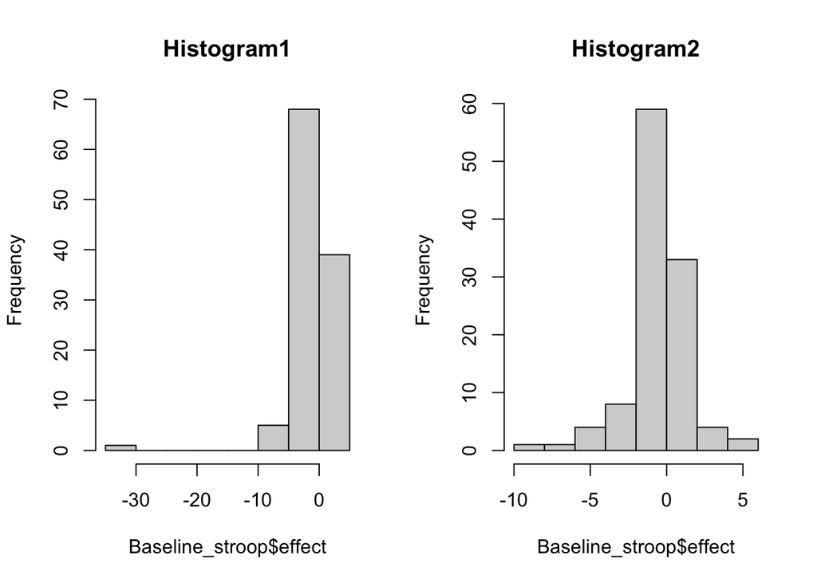

```r
par(mfrow=c(1,2))
hist(Baseline_stroop$effect, main="Histogram1")
Baseline_stroop <- filter(Baseline_stroop, effect > -20)
hist(Baseline_stroop$effect, main="Histogram2")
```

Now, let’s consider the balance of explanatory variables. After checking all variables, I found variable education has an incorrect value “Do not know” and variable Fall has an incorrect value “Don’t Know”. The patients of the two incorrect values should not be involved in further analysis. On the other hand, the six item screener questions should be combined into one variable. If the value of one screener is ‘yes’, we rewrite it as 1. If the value of one screener is ‘no’, we rewrite it as 0. Then, sum all 1s and 0s together to get the variable sis. The code is shown below:

```r
Baseline_stroop <- filter(Baseline_stroop, Education != "Do not know")
Baseline_stroop <- filter(Baseline_stroop, Fall != "Don't Know")

sis <- rep(0,length(Baseline_stroop$pt))
for (i in 1:length(Baseline_stroop$Age)){
  if (Baseline_stroop$sis_1a[i] == "Yes"){
    sis[i] = sis[i] + 1
  }
  if (Baseline_stroop$sis_2a[i] == "Yes"){
    sis[i] = sis[i] + 1
  }
  if (Baseline_stroop$sis_3a[i] == "Yes"){
    sis[i] = sis[i] + 1
  }
  if (Baseline_stroop$sis_1b[i] == "Yes"){
    sis[i] = sis[i] + 1
  }
  if (Baseline_stroop$sis_2b[i] == "Yes"){
    sis[i] = sis[i] + 1
  }
  if (Baseline_stroop$sis_3b[i] == "Yes"){
    sis[i] = sis[i] + 1
  }
  if (Baseline_stroop$sis_4[i] == "Yes"){
    sis[i] = sis[i] + 1
  }
  if (Baseline_stroop$sis_5[i] == "Yes"){
    sis[i] = sis[i] + 1
  }
  if (Baseline_stroop$sis_6[i] == "Yes"){
    sis[i] = sis[i] + 1
  }
}
Baseline_stroop$sis <- sis
```

## 5.2 Preprocessing of Categorical and Counting Variables

Before doing regression analysis, we still need to consider preprocessing categorical and counting variables. Since there is only one categorical variable sis, we do not consider any preprocess for it such as Minimax. However, for categorical variables, we create dummy variables for each one. The code for creating dummy variables for categorical variables is shown below:

```r
#Preprocessing for categorical variables and counting variables
Gender_1 <- factor(Baseline_stroop$Gender)
dummy_Gender <- model.matrix(~ Gender_1 - 1)
Baseline_stroop$dummy_Gender <- dummy_Gender

Edu_1 <- factor(Baseline_stroop$Education)
dummy_Education <- model.matrix(~ Edu_1 - 1)
Baseline_stroop$dummy_Education <- dummy_Education

Inter_1 <- factor(Baseline_stroop$Intervention)
dummy_Intervention <- model.matrix(~ Inter_1 - 1)
Baseline_stroop$dummy_Intervention <- dummy_Intervention

head_1 <- factor(Baseline_stroop$head)
dummy_head <- model.matrix(~ head_1 - 1)
Baseline_stroop$dummy_head <- dummy_head

Device_1 <- factor(Baseline_stroop$Device)
dummy_Device <- model.matrix(~ Device_1 - 1)
Baseline_stroop$dummy_Device <- dummy_Device

Fall_1 <- factor(Baseline_stroop$Fall)
dummy_Fall <- model.matrix(~ Fall_1 - 1)
Baseline_stroop$dummy_Fall <- dummy_Fall
```

## 5.3 Regression models for stroop test

$$E[ST_{i1}]=\beta_0+\beta_1Age_{i1}+\beta_2Male_i+\beta_3Education_i$$
$$E[ST_{i1}]=\beta_0+\beta_1Assistive
Device_{i1}+\beta_2Age_{i1}+\beta_2Male_i+\beta_2Education_i$$
$$E[ST_{i1}]=\beta_0+\beta_1Cognitive
Impairment_{i1}+\beta_2Age_{i1}+\beta_2Male_i+\beta_2Education_i$$
$$E[ST_{i1}]=\beta_0+\beta_1Head
Strike_{i1}+\beta_2Age_{i1}+\beta_2Male_i+\beta_2Education_i$$
$$E[ST_{i1}]=\beta_0+\beta_1Fall
History_{i1}+\beta_2Age_{i1}+\beta_2Male_i+\beta_2Education_i$$

```r
#Regression models
model1_p <- lm(effect ~ Age + Gender + Education, data=Baseline_stroop)
model2_p <- lm(effect ~ Age + Gender + Education + Device, data=Baseline_stroop)
model3_p <- lm(effect ~ Age + Gender + Education + sis, data=Baseline_stroop)
model4_p <- lm(effect ~ Age + Gender + Education + head, data=Baseline_stroop)
model5_p <- lm(effect ~ Age + Gender + Education + Fall, data=Baseline_stroop)

#Regression models
model1 <- lm(effect ~ Age + dummy_Gender + dummy_Education, data=Baseline_stroop)
model2 <- lm(effect ~ Age + dummy_Gender + dummy_Education + dummy_Device, data=Baseline_stroop)
model3 <- lm(effect ~ Age + dummy_Gender + dummy_Education + sis, data=Baseline_stroop)
model4 <- lm(effect ~ Age + dummy_Gender + dummy_Education + dummy_head, data=Baseline_stroop)
model5 <- lm(effect ~ Age + dummy_Gender + dummy_Education + dummy_Fall, data=Baseline_stroop)
```

## 5.4 Check Assumptions for Regression Models

Even if we have built our models, we should check some assumptions for these models before using their outcomes. Firstly, we should check the collinearity and independence of explanatory variables. For collinearity, I used variance inflation factor to check. In general, the VIF should be near 1 and not to large. All VIFs in all five models are between 1.0 to 1.3 which are good enough. For the independence, I used Durbin–Watson statistic to check. In general, the Durbin–Watson statistic should be near 2. The Durbin–Watson statistic for five models are 1.93, 1.93, 1.87, 1.93, and 1.94 which are also good enough. Therefore, the assumptions of collinearity and independence are satisifed.

```r
#Durbin-Watson
D1 <- durbinWatsonTest(model1)
D2 <- durbinWatsonTest(model2)
D3 <- durbinWatsonTest(model3)
D4 <- durbinWatsonTest(model4)
D5 <- durbinWatsonTest(model5)

#VIF Score
DD1 <- car::vif(model1_p)
DD2 <- car::vif(model2_p)
DD3 <- car::vif(model3_p)
DD4 <- car::vif(model4_p)
DD5 <- car::vif(model5_p)
```

Secondly, we should check the residual plots and qqplots for each model. In general, the residual line should follow the line $y=0$ and the line in qqplot should follow $y=x$. The plots for each model are shown below.

Residual plots:

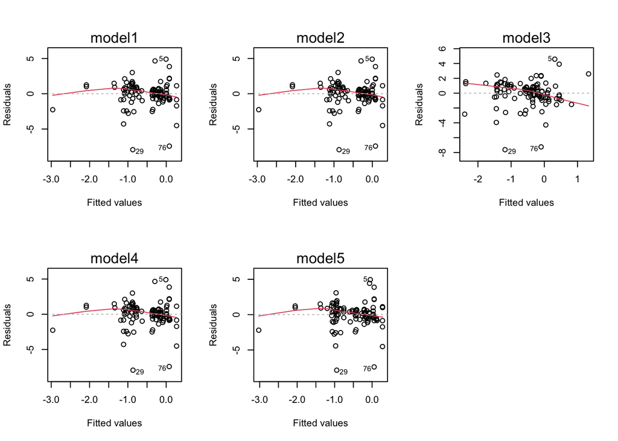

```r
par(mfrow=c(2,3))
plot(model1, which = 1, xlab("model1")) #Residual plot
plot(model2, which = 1, xlab("model2")) #Residual plot
plot(model3, which = 1, xlab("model3")) #Residual plot
plot(model4, which = 1, xlab("model4")) #Residual plot
plot(model5, which = 1, xlab("model5")) #Residual plot
```

Q-Q plots:

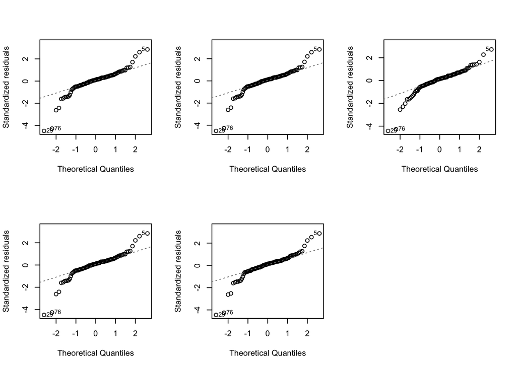

```r
par(mfrow=c(2,3))
plot(model1, which = 2, xlab("model1")) #Normality plot
plot(model2, which = 2, xlab("model2")) #Normality plot
plot(model3, which = 2, xlab("model3")) #Normality plot
plot(model4, which = 2, xlab("model4")) #Normality plot
plot(model5, which = 2, xlab("model5")) #Normality plot
```

## 5.5 Outcomes for regression models of stroop test

Outcomes for model 1:

```r
export_summs(model1_p, model.names=c("Hypothesis 1"))
```

|  | Hypothesis 1 |
| --- | --- |
| (Intercept) | 1.04 |
|  | (1.84) |
| Age | -0.01 |
|  | (0.02) |
| GenderMale | -0.78 |
|  | (0.39) |
| EducationCollege 4 years or more (College graduate) | -0.17 |
|  | (0.42) |
| EducationGrades 1 through 8 (Elementary/middle school) | -2.03 |
|  | (1.10) |
| EducationGrades 12 or GED (High school graduate) | -0.65 |
|  | (0.62) |
| EducationGrades 9 through 11 (Some high school) | 0.18 |
|  | (0.63) |
| N | 110 |
| R2 | 0.08 |
| *** p < 0.001; ** p < 0.01; * p < 0.05. |  |

```r
model_summary_1 <- summary(model1)
model_summary_1$coefficients[, "Pr(>|t|)"]
```

```
##                                                                      (Intercept)
##                                                                       0.81519934
##                                                                              Age
##                                                                       0.54081767
##                                                       dummy_GenderGender_1Female
##                                                                       0.05026051
## dummy_EducationEdu_1College 1 year to 3 years (Some college or technical school)
##                                                                       0.77964898
##                   dummy_EducationEdu_1College 4 years or more (College graduate)
##                                                                       0.56184256
##                dummy_EducationEdu_1Grades 1 through 8 (Elementary/middle school)
##                                                                       0.06312988
##                      dummy_EducationEdu_1Grades 12 or GED (High school graduate)
##                                                                       0.26705234
```

Outcomes for model 2:

```r
export_summs(model2_p, model.names=c("Hypothesis 2"))
```

|  | Hypothesis 2 |
| --- | --- |
| (Intercept) | 1.03 |
|  | (1.88) |
| Age | -0.01 |
|  | (0.03) |
| GenderMale | -0.78 |
|  | (0.41) |
| EducationCollege 4 years or more (College graduate) | -0.17 |
|  | (0.43) |
| EducationGrades 1 through 8 (Elementary/middle school) | -2.03 |
|  | (1.12) |
| EducationGrades 12 or GED (High school graduate) | -0.65 |
|  | (0.62) |
| EducationGrades 9 through 11 (Some high school) | 0.18 |
|  | (0.65) |
| DeviceYes | -0.01 |
|  | (0.46) |
| N | 110 |
| R2 | 0.08 |
| *** p < 0.001; ** p < 0.01; * p < 0.05. |  |

```r
model_summary_2 <- summary(model2)
model_summary_2$coefficients[, "Pr(>|t|)"]
```

```
##                                                                      (Intercept)
##                                                                       0.83545203
##                                                                              Age
##                                                                       0.57170386
##                                                       dummy_GenderGender_1Female
##                                                                       0.05772303
## dummy_EducationEdu_1College 1 year to 3 years (Some college or technical school)
##                                                                       0.78210702
##                   dummy_EducationEdu_1College 4 years or more (College graduate)
##                                                                       0.56593456
##                dummy_EducationEdu_1Grades 1 through 8 (Elementary/middle school)
##                                                                       0.06444820
##                      dummy_EducationEdu_1Grades 12 or GED (High school graduate)
##                                                                       0.28688776
##                                                           dummy_DeviceDevice_1No
##                                                                       0.97862326
```

Outcomes for model 3:

```r
export_summs(model3_p, model.names=c("Hypothesis 3"))
```

|  | Hypothesis 3 |
| --- | --- |
| (Intercept) | 4.86 |
|  | (2.48) |
| Age | -0.01 |
|  | (0.02) |
| GenderMale | -0.91 * |
|  | (0.39) |
| EducationCollege 4 years or more (College graduate) | -0.21 |
|  | (0.41) |
| EducationGrades 1 through 8 (Elementary/middle school) | -2.12 |
|  | (1.08) |
| EducationGrades 12 or GED (High school graduate) | -0.71 |
|  | (0.61) |
| EducationGrades 9 through 11 (Some high school) | 0.18 |
|  | (0.62) |
| sis | -0.48 * |
|  | (0.21) |
| N | 110 |
| R2 | 0.13 |
| *** p < 0.001; ** p < 0.01; * p < 0.05. |  |

```r
model_summary_3 <- summary(model3)
model_summary_3$coefficients[, "Pr(>|t|)"]
```

```
##                                                                      (Intercept)
##                                                                       0.09473761
##                                                                              Age
##                                                                       0.64120196
##                                                       dummy_GenderGender_1Female
##                                                                       0.02138283
## dummy_EducationEdu_1College 1 year to 3 years (Some college or technical school)
##                                                                       0.77399030
##                   dummy_EducationEdu_1College 4 years or more (College graduate)
##                                                                       0.50730242
##                dummy_EducationEdu_1Grades 1 through 8 (Elementary/middle school)
##                                                                       0.04854172
##                      dummy_EducationEdu_1Grades 12 or GED (High school graduate)
##                                                                       0.22450907
##                                                                              sis
##                                                                       0.02583046
```

Outcomes for model 4:

```r
export_summs(model4_p, model.names=c("Hypothesis 4"))
```

|  | Hypothesis 4 |
| --- | --- |
| (Intercept) | 0.98 |
|  | (2.11) |
| Age | -0.01 |
|  | (0.02) |
| GenderMale | -0.77 |
|  | (0.40) |
| EducationCollege 4 years or more (College graduate) | -0.17 |
|  | (0.43) |
| EducationGrades 1 through 8 (Elementary/middle school) | -2.04 |
|  | (1.11) |
| EducationGrades 12 or GED (High school graduate) | -0.65 |
|  | (0.62) |
| EducationGrades 9 through 11 (Some high school) | 0.17 |
|  | (0.64) |
| headUnchecked | 0.07 |
|  | (1.38) |
| N | 110 |
| R2 | 0.08 |
| *** p < 0.001; ** p < 0.01; * p < 0.05. |  |

```r
model_summary_4 <- summary(model4)
model_summary_4$coefficients[, "Pr(>|t|)"]
```

```
##                                                                      (Intercept)
##                                                                       0.81147043
##                                                                              Age
##                                                                       0.54231371
##                                                       dummy_GenderGender_1Female
##                                                                       0.05652848
## dummy_EducationEdu_1College 1 year to 3 years (Some college or technical school)
##                                                                       0.78672249
##                   dummy_EducationEdu_1College 4 years or more (College graduate)
##                                                                       0.56335854
##                dummy_EducationEdu_1Grades 1 through 8 (Elementary/middle school)
##                                                                       0.06437612
##                      dummy_EducationEdu_1Grades 12 or GED (High school graduate)
##                                                                       0.27055468
##                                                          dummy_headhead_1Checked
##                                                                       0.95714482
```

Outcomes for model 5:

```r
export_summs(model5_p, model.names=c("Hypothesis 5"))
```

|  | Hypothesis 5 |
| --- | --- |
| (Intercept) | 1.54 |
|  | (2.07) |
| Age | -0.02 |
|  | (0.02) |
| GenderMale | -0.85 * |
|  | (0.42) |
| EducationCollege 4 years or more (College graduate) | -0.24 |
|  | (0.44) |
| EducationGrades 1 through 8 (Elementary/middle school) | -2.01 |
|  | (1.10) |
| EducationGrades 12 or GED (High school graduate) | -0.63 |
|  | (0.62) |
| EducationGrades 9 through 11 (Some high school) | 0.15 |
|  | (0.64) |
| FallYes | -0.29 |
|  | (0.54) |
| N | 110 |
| R2 | 0.09 |
| *** p < 0.001; ** p < 0.01; * p < 0.05. |  |

```r
model_summary_5 <- summary(model5)
model_summary_5$coefficients[, "Pr(>|t|)"]
```

```
##                                                                      (Intercept)
##                                                                       0.77447142
##                                                                              Age
##                                                                       0.48035178
##                                                       dummy_GenderGender_1Female
##                                                                       0.04356240
## dummy_EducationEdu_1College 1 year to 3 years (Some college or technical school)
##                                                                       0.81947947
##                   dummy_EducationEdu_1College 4 years or more (College graduate)
##                                                                       0.52436786
##                dummy_EducationEdu_1Grades 1 through 8 (Elementary/middle school)
##                                                                       0.07099687
##                      dummy_EducationEdu_1Grades 12 or GED (High school graduate)
##                                                                       0.30263303
##                                                               dummy_FallFall_1No
##                                                                       0.58480687
```

# 6 Summary